# DATA605_HW12

Gabriel Santos

2022-11-07

### The attached who.csv dataset contains real-world data from 2008.

#### The variables.

- Country: name of the country.
- LifeExp: average life expectancy for the country in years.
- InfantSurvival: proportion of those surviving to one year or more.
- Under5Survival: proportion of those surviving to five years or more.
- TBFree: proportion of the population without TB.
- PropMD: proportion of the population who are MDs.
- PropRN: proportion of the population who are RNs.
- PersExp: mean personal expenditures on healthcare in US dollars at average exchange rate.
- GovtExp: mean government expenditures per capita on healthcare, US dollars at average exchange rate.
- TotExp: sum of personal and government expenditures.

#### The libraries

```r
library(ggplot2)
library(tidyverse)
```

#### Data Import

```r
who <- read.csv('https://raw.githubusercontent.com/GabrielSantos33/DATA605_HW12/main/who.csv')
summary(who)
```

```
##    Country             LifeExp      InfantSurvival   Under5Survival
##  Length:190         Min.   :40.00   Min.   :0.8350   Min.   :0.7310
##  Class :character   1st Qu.:61.25   1st Qu.:0.9433   1st Qu.:0.9253
##  Mode  :character   Median :70.00   Median :0.9785   Median :0.9745
##                     Mean   :67.38   Mean   :0.9624   Mean   :0.9459
##                     3rd Qu.:75.00   3rd Qu.:0.9910   3rd Qu.:0.9900
##                     Max.   :83.00   Max.   :0.9980   Max.   :0.9970
##      TBFree           PropMD              PropRN             PersExp
##  Min.   :0.9870   Min.   :0.0000196   Min.   :0.0000883   Min.   :   3.00
##  1st Qu.:0.9969   1st Qu.:0.0002444   1st Qu.:0.0008455   1st Qu.:  36.25
##  Median :0.9992   Median :0.0010474   Median :0.0027584   Median : 199.50
##  Mean   :0.9980   Mean   :0.0017954   Mean   :0.0041336   Mean   : 742.00
##  3rd Qu.:0.9998   3rd Qu.:0.0024584   3rd Qu.:0.0057164   3rd Qu.: 515.25
##  Max.   :1.0000   Max.   :0.0351290   Max.   :0.0708387   Max.   :6350.00
##     GovtExp             TotExp
##  Min.   :    10.0   Min.   :    13
##  1st Qu.:   559.5   1st Qu.:   584
##  Median :  5385.0   Median :  5541
##  Mean   : 40953.5   Mean   : 41696
##  3rd Qu.: 25680.2   3rd Qu.: 26331
##  Max.   :476420.0   Max.   :482750
```

```r
head(who)
```

```
##               Country LifeExp InfantSurvival Under5Survival  TBFree      PropMD
## 1         Afghanistan      42          0.835          0.743 0.99769 0.000228841
## 2             Albania      71          0.985          0.983 0.99974 0.001143127
## 3             Algeria      71          0.967          0.962 0.99944 0.001060478
## 4             Andorra      82          0.997          0.996 0.99983 0.003297297
## 5              Angola      41          0.846          0.740 0.99656 0.000070400
## 6 Antigua and Barbuda      73          0.990          0.989 0.99991 0.000142857
##        PropRN PersExp GovtExp TotExp
## 1 0.000572294      20      92    112
## 2 0.004614439     169    3128   3297
## 3 0.002091362     108    5184   5292
## 4 0.003500000    2589  169725 172314
## 5 0.001146162      36    1620   1656
## 6 0.002773810     503   12543  13046
```

## Question 1

#### Provide a scatterplot of LifeExp~TotExp, and run simple linear regression. Do not transform the variables. Provide and interpret the F statistics, R^2, standard error,and p-values only. Discuss whether the assumptions of simple linear regression met.

#### Data Exploration

```r
who.lm <- lm(LifeExp~TotExp, data=who)
summary(who.lm)
```

```
##
## Call:
## lm(formula = LifeExp ~ TotExp, data = who)
##
## Residuals:
##     Min      1Q  Median      3Q     Max
## -24.764  -4.778   3.154   7.116  13.292
##
## Coefficients:
##              Estimate Std. Error t value Pr(>|t|)
## (Intercept) 6.475e+01  7.535e-01  85.933  < 2e-16 ***
## TotExp      6.297e-05  7.795e-06   8.079 7.71e-14 ***
## ---
## Signif. codes:  0 '***' 0.001 '**' 0.01 '*' 0.05 '.' 0.1 ' ' 1
##
## Residual standard error: 9.371 on 188 degrees of freedom
## Multiple R-squared:  0.2577, Adjusted R-squared:  0.2537
## F-statistic: 65.26 on 1 and 188 DF,  p-value: 7.714e-14
```

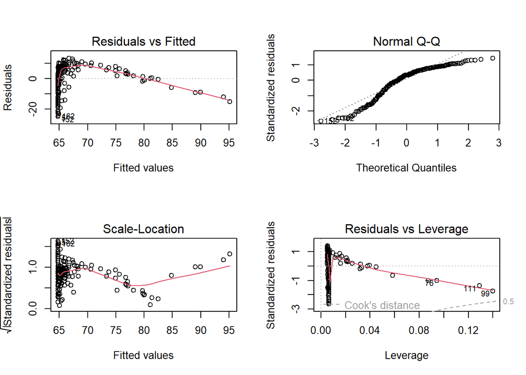

```r
par(mfrow=c(2,2)) #prints out two rows, two columns of plots
plot(who.lm)
```

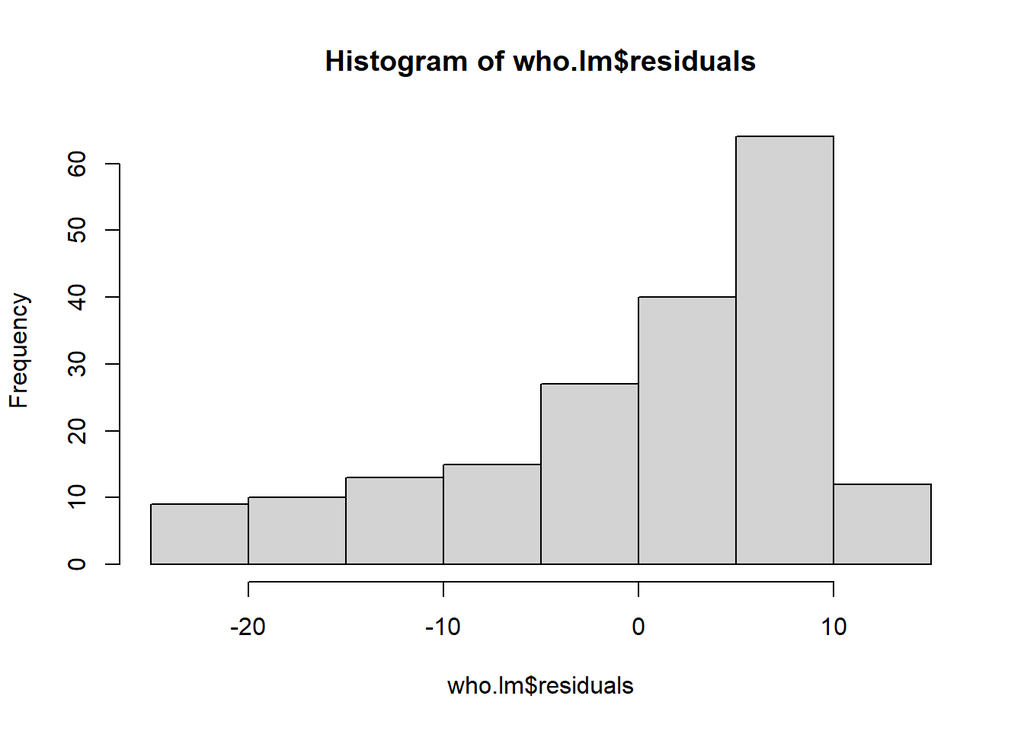

```r
hist(who.lm$residuals)
```

#### Are the assumptions of simple linear regression met?

#### No, the conditions are not met.

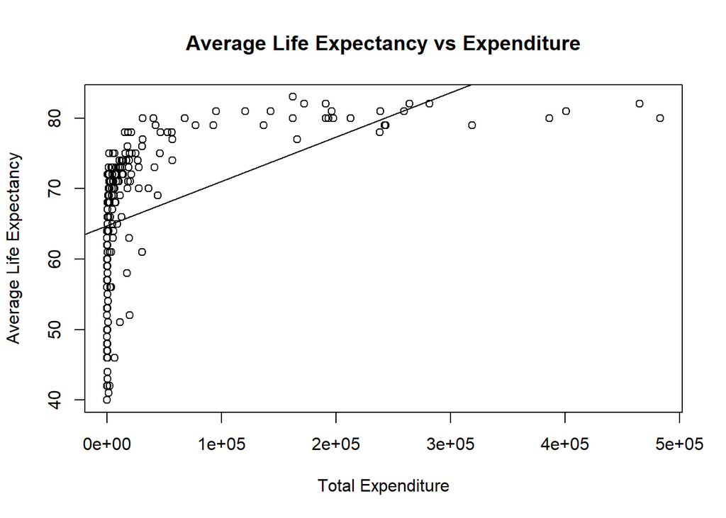

```r
#scatterplot
lm <- lm(LifeExp ~ TotExp, data = who)
plot(who$TotExp, who$LifeExp, xlab = 'Total Expenditure', ylab = 'Average Life Expectancy', main='Average Life Expectancy vs Expenditure')
abline(lm)
```

```r
summary(lm)
```

```
##
## Call:
## lm(formula = LifeExp ~ TotExp, data = who)
##
## Residuals:
##     Min      1Q  Median      3Q     Max
## -24.764  -4.778   3.154   7.116  13.292
##
## Coefficients:
##              Estimate Std. Error t value Pr(>|t|)
## (Intercept) 6.475e+01  7.535e-01  85.933  < 2e-16 ***
## TotExp      6.297e-05  7.795e-06   8.079 7.71e-14 ***
## ---
## Signif. codes:  0 '***' 0.001 '**' 0.01 '*' 0.05 '.' 0.1 ' ' 1
##
## Residual standard error: 9.371 on 188 degrees of freedom
## Multiple R-squared:  0.2577, Adjusted R-squared:  0.2537
## F-statistic: 65.26 on 1 and 188 DF,  p-value: 7.714e-14
```

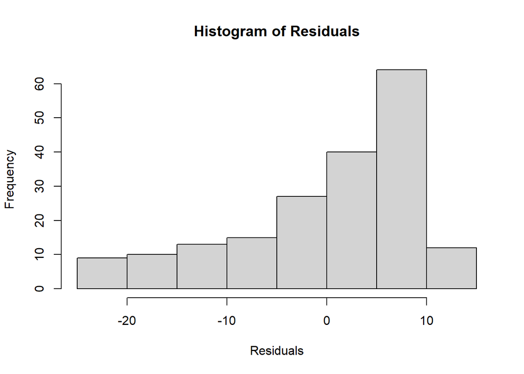

```r
#plots
hist(resid(lm), main = "Histogram of Residuals", xlab = "Residuals")
```

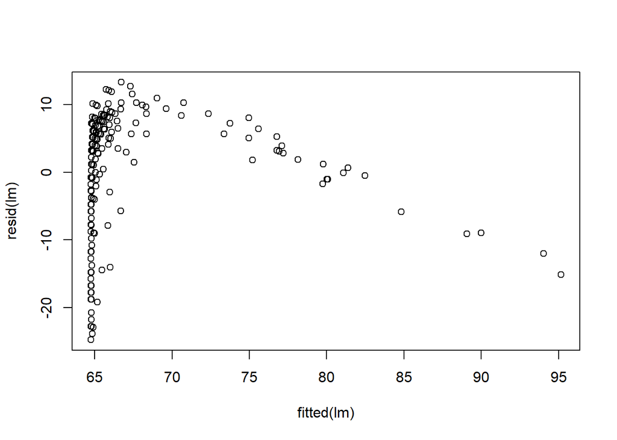

```r
plot(fitted(lm), resid(lm))
```

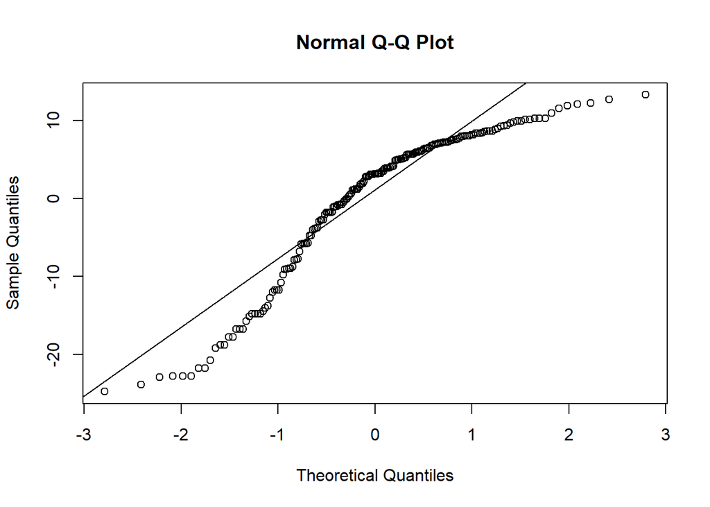

```r
qqnorm(lm$residuals)
qqline(lm$residuals)
```

#### By seeing the R^2 value, we can say that the explained variability is very less @25.77%. The p-value suggests a statistically significant correlation between total expenditures and life expectancy, since p<<0.05. Looking at residuals plots it is clear that there is no constant variability and that residuals are not normally distributed. This model is not a good model.

## Question 2

#### Raise life expectancy to the 4.6 power (i.e., LifeExp^4.6). Raise total expenditures to the 0.06 power (nearly a log transform, TotExp^.06). Plot LifeExp^4.6 as a function of TotExp^.06, and r re-run the simple regression model using the transformed variables. Provide and interpret the F statistics, R^2, standard error, and p-values. Which model is “better?”

```r
#model2
LifeExp46 <- who$LifeExp**4.6
TotExp06 <- who$TotExp**0.06
lm1 <- lm(LifeExp46 ~ TotExp06, data = who)
summary(lm1)
```

```
##
## Call:
## lm(formula = LifeExp46 ~ TotExp06, data = who)
##
## Residuals:
##        Min         1Q     Median         3Q        Max
## -308616089  -53978977   13697187   59139231  211951764
##
## Coefficients:
##               Estimate Std. Error t value Pr(>|t|)
## (Intercept) -736527910   46817945  -15.73   <2e-16 ***
## TotExp06     620060216   27518940   22.53   <2e-16 ***
## ---
## Signif. codes:  0 '***' 0.001 '**' 0.01 '*' 0.05 '.' 0.1 ' ' 1
##
## Residual standard error: 90490000 on 188 degrees of freedom
## Multiple R-squared:  0.7298, Adjusted R-squared:  0.7283
## F-statistic: 507.7 on 1 and 188 DF,  p-value: < 2.2e-16
```

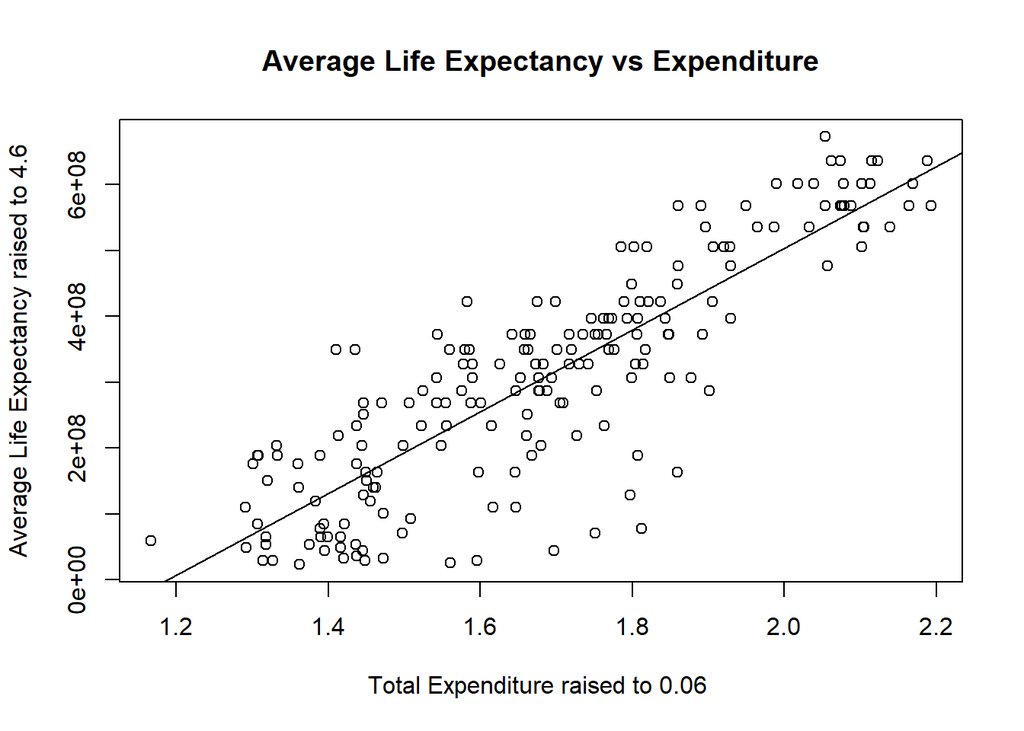

```r
plot(who$TotExp**0.06, who$LifeExp**4.6, xlab = 'Total Expenditure raised to 0.06 ', ylab = 'Average Life Expectancy raised to 4.6', main='Average Life Expectancy vs Expenditure')
abline(lm1)
```

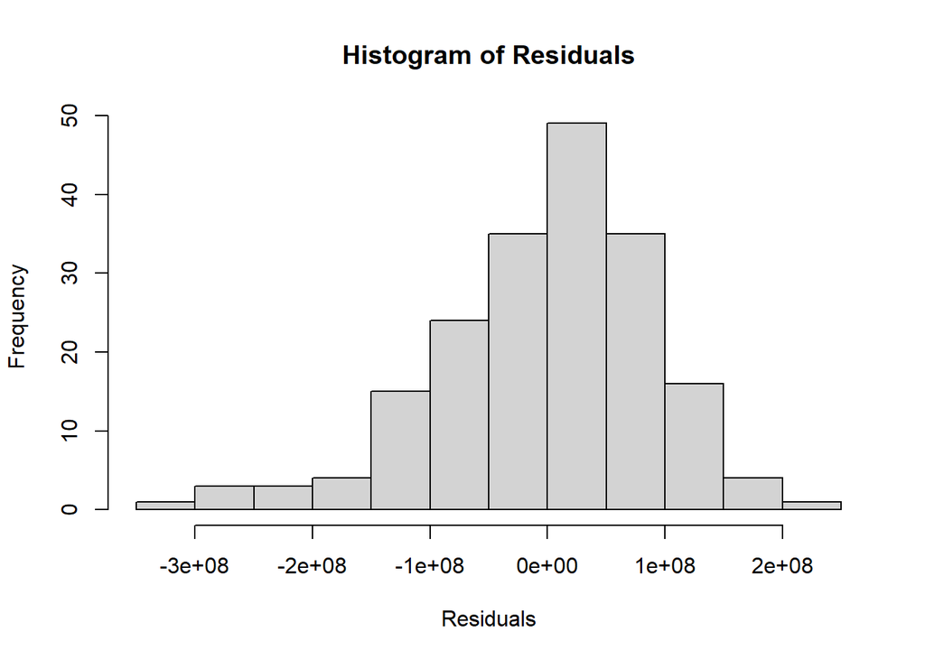

```r
#plots
hist(resid(lm1), main = "Histogram of Residuals", xlab = "Residuals")
```

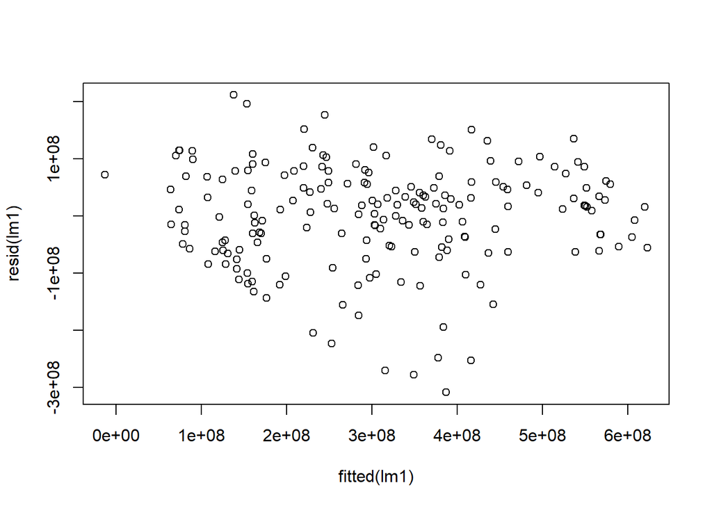

```r
plot(fitted(lm1), resid(lm1))
```

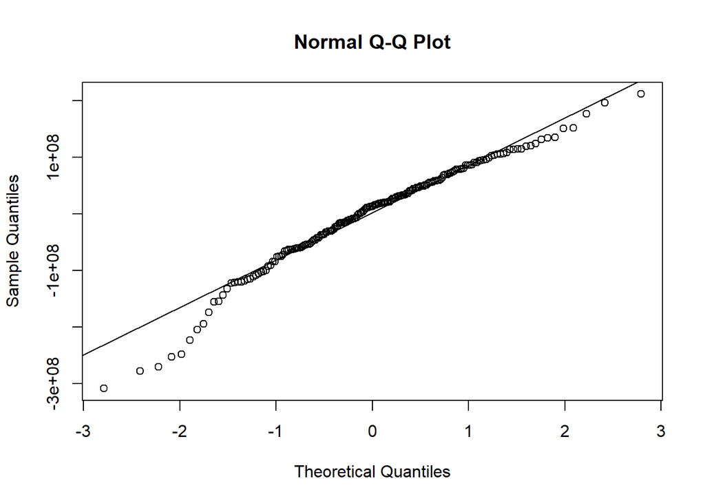

```r
qqnorm(lm1$residuals)
qqline(lm1$residuals)
```

```r
who2 <- who %>%
  mutate(LifeExp2 = LifeExp^4.6,
         TotExp2 = TotExp^.06)
who.lm2 <- lm(LifeExp2~TotExp2, data=who2)
summary(who.lm2)
```

```
##
## Call:
## lm(formula = LifeExp2 ~ TotExp2, data = who2)
##
## Residuals:
##        Min         1Q     Median         3Q        Max
## -308616089  -53978977   13697187   59139231  211951764
##
## Coefficients:
##               Estimate Std. Error t value Pr(>|t|)
## (Intercept) -736527910   46817945  -15.73   <2e-16 ***
## TotExp2      620060216   27518940   22.53   <2e-16 ***
## ---
## Signif. codes:  0 '***' 0.001 '**' 0.01 '*' 0.05 '.' 0.1 ' ' 1
##
## Residual standard error: 90490000 on 188 degrees of freedom
## Multiple R-squared:  0.7298, Adjusted R-squared:  0.7283
## F-statistic: 507.7 on 1 and 188 DF,  p-value: < 2.2e-16
```

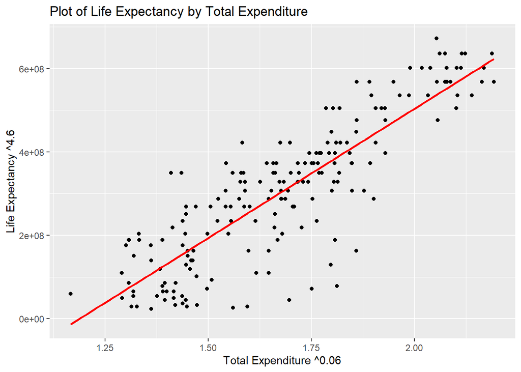

```r
ggplot(who2, aes(x =TotExp2 , y = LifeExp2)) +
  geom_point()+
  geom_smooth(method = "lm", formula = y ~ x, se = FALSE, col="red")+
  ggtitle("Plot of Life Expectancy by Total Expenditure") +
  xlab("Total Expenditure ^0.06") + ylab("Life Expectancy ^4.6")
```

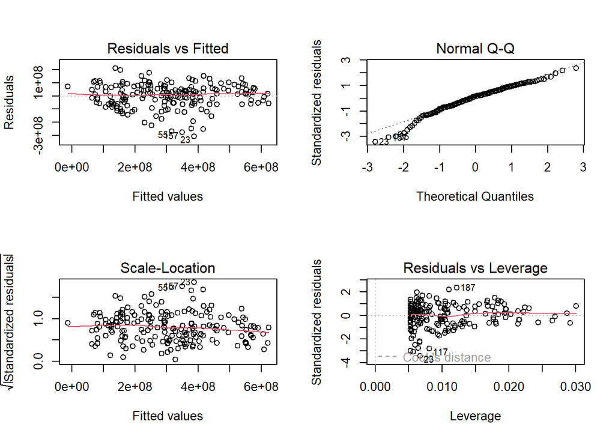

```r
par(mfrow=c(2,2))
plot(who.lm2)
```

#### The 2nd model is better than the 1st model. The R^2 is .729, that means the explained variability is 72.9% compared to 25% for the1st model. Looking at residuals plots, variability is fairly constant with a few outliers and distribution of residuals is nearly normal. So 2nd model is better than the 1st model.

## Questions 3

#### Using the results from 3, forecast life expectancy when TotExp^.06 =1.5. Then forecast life expectancy when TotExp^.06=2.5.

#### The equation:

#### y = - 736527910 + 620060216*(x)

```r
x = 1.5
y <- (-736527910 + 620060216*x)
y
```

```
## [1] 193562414
```

```r
LE <- function(x)
{y <- -736527910 + 620060216 *(x)
y <- y^(1/4.6)
y}
LE(1.5)
```

```
## [1] 63.31153
```

```r
LE(2.5)
```

```
## [1] 86.50645
```

#### Life expectancy when TotExp.06 = 1.5 is approximately 63.3

```r
x = 2.5
y <- (-736527910 + 620060216*x)
y
```

```
## [1] 813622630
```

```r
(y)^(1/4.6)
```

```
## [1] 86.50645
```

### Life expectancy when TotExp.06=2.5 is approximately 86.5

## Question 4

#### Build the following multiple regression model and interpret the F Statistics, R^2, standard error, and p-values. How good is the model?

#### LifeExp = b0+b1 x PropMd + b2 x TotExp +b3 x PropMD x TotExp

```r
#model3
who.lm3 <- lm(LifeExp~TotExp + PropMD + PropMD * TotExp, data=who)
summary(who.lm3)
```

```
##
## Call:
## lm(formula = LifeExp ~ TotExp + PropMD + PropMD * TotExp, data = who)
##
## Residuals:
##     Min      1Q  Median      3Q     Max
## -27.320  -4.132   2.098   6.540  13.074
##
## Coefficients:
##                 Estimate Std. Error t value Pr(>|t|)
## (Intercept)    6.277e+01  7.956e-01  78.899  < 2e-16 ***
## TotExp         7.233e-05  8.982e-06   8.053 9.39e-14 ***
## PropMD         1.497e+03  2.788e+02   5.371 2.32e-07 ***
## TotExp:PropMD -6.026e-03  1.472e-03  -4.093 6.35e-05 ***
## ---
## Signif. codes:  0 '***' 0.001 '**' 0.01 '*' 0.05 '.' 0.1 ' ' 1
##
## Residual standard error: 8.765 on 186 degrees of freedom
## Multiple R-squared:  0.3574, Adjusted R-squared:  0.3471
## F-statistic: 34.49 on 3 and 186 DF,  p-value: < 2.2e-16
```

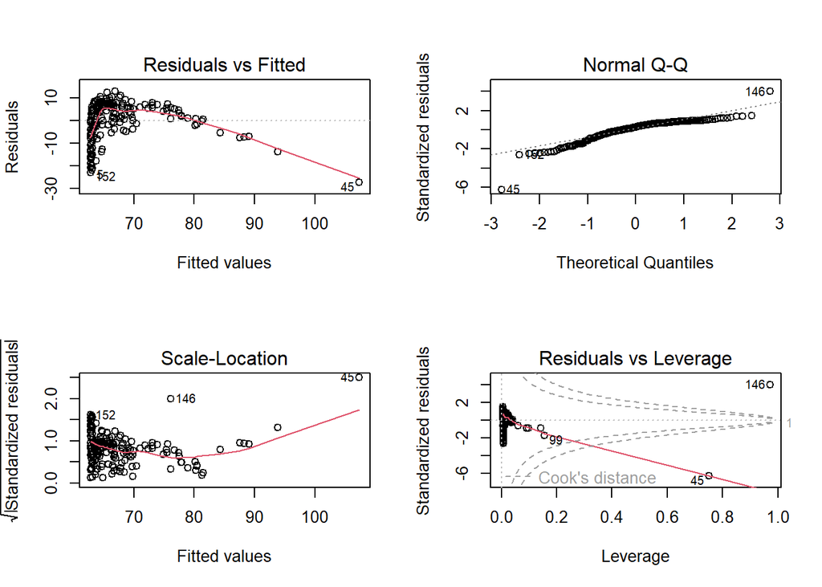

```r
par(mfrow=c(2,2))
plot(who.lm3)
```

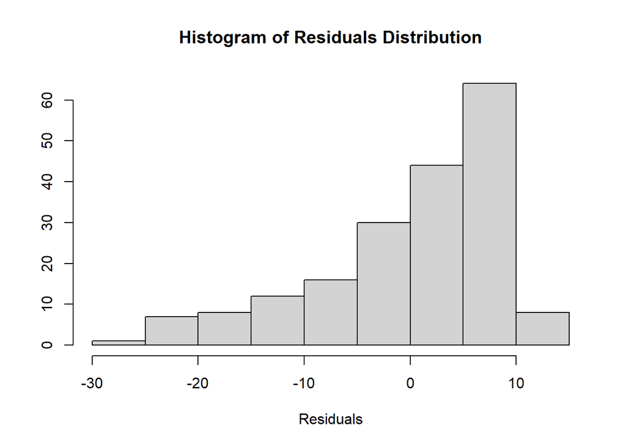

```r
par(mfrow=c(1,1))
# residuals histogram
hist(who.lm3$residuals,
     xlab = "Residuals", ylab = "",
     main = "Histogram of Residuals Distribution")
```

#### Are the assumptions of simple linear regression met?

- Linearity: The relationship between X and the mean of Y is not linear. Based on the Residuals vs. Fitted plot, the the red line exhibits a quadratic relationship and is not linear.
- Homoscedasticity: The variance of residual is not the same for any value of X. The Scale-Location plot shows the residuals are not spread equally along the ranges of predictor.
- Independence: Observations are not independent of each other. Upon examining the Residuals vs. Fitted plot, we can see a correlation between the variables.
- Multivariate Normality: The nearly normal residual condition doesn’t seem to be met based on the histogram of residuals shown below show the residuals are heavily left skew.

#### How good is the model? Are the assumptions of simple linear regression met?

#### The model is not that great given the criteria mentioned above because the conditions are not met

## Question 5

#### Forecast LifeExp when PropMD=.03 and TotExp = 14. Does this forecast seem realistic? Why or why not?

```r
b0 <- 6.277 * 10^1
b1 <- 1.497 * 10^3
b2 <- 7.233 * 10^-5
b3 <- -6.026 * 10^-3
#PropMD
x1 <- .03
#TotExp
x2 <- 14
```

```r
max(who$LifeExp)
```

```
## [1] 83
```

```r
mean(who$LifeExp)
```

```
## [1] 67.37895
```

```r
LifeExp_new <- ( (6.277*10^1) + (1.497*10^3)*.03 + (7.233*10^(-5))*14 - ((6.026*10^(-3))*0.03*14) )
LifeExp_new
```

```
## [1] 107.6785
```

#### This seems like an outlier as life expectancy of 107 does not look correct. The forecasted life expectancy using the linear model from exercise 4 is 107.7. This forecast is unrealistic with the actual data because the maximum life expectancy from the WHO data is 83 and the mean of all life expectancies is 67.4.